# RALLI_FT

2023-10-19

*ELENI RALLI*

*A.M. : f2822312*

## Assigment 2

### 1) Load the data in an object named Drugs. You will notice there is an additional variable called FLAG CODES. Remove this variable from the dataset. (0.5 point)

```r
#file.choose()  #to easily find the file path
# it is  "D:\\2 assigmanet in R\\Drugs.txt" so :
Drugs<-read.table("D:\\2 assigmanet in R\\Drugs.txt", header=TRUE, sep= ",")
```

to see my data and see if it was read correctly :

```r
str(Drugs)
```

```
## 'data.frame':    1036 obs. of  7 variables:
##  $ LOCATION   : chr  "AUS" "AUS" "AUS" "AUS" ...
##  $ TIME       : int  1971 1972 1973 1974 1975 1976 1977 1978 1979 1980 ...
##  $ PC_HEALTHXP: num  16 15.1 15.1 14.8 11.8 ...
##  $ PC_GDP     : num  0.727 0.686 0.681 0.755 0.682 0.63 0.613 0.591 0.523 0.54 ...
##  $ USD_CAP    : num  35.7 36.1 39.9 47.6 47.6 ...
##  $ FLAG_CODES : chr  "" "" "" "" ...
##  $ TOTAL_SPEND: num  462 475 533 653 661 ...
```

```r
head(Drugs)
```

```
##   LOCATION TIME PC_HEALTHXP PC_GDP USD_CAP FLAG_CODES TOTAL_SPEND
## 1      AUS 1971      15.992  0.727  35.720                 462.11
## 2      AUS 1972      15.091  0.686  36.056                 475.11
## 3      AUS 1973      15.117  0.681  39.871                 533.47
## 4      AUS 1974      14.771  0.755  47.559                 652.65
## 5      AUS 1975      11.849  0.682  47.561                 660.76
## 6      AUS 1976      10.920  0.630  46.908                 658.26
```

```r
Drugs<-Drugs[,-6]  # remove the variable FLAG CODES
head(Drugs)  # ok
```

```
##   LOCATION TIME PC_HEALTHXP PC_GDP USD_CAP TOTAL_SPEND
## 1      AUS 1971      15.992  0.727  35.720      462.11
## 2      AUS 1972      15.091  0.686  36.056      475.11
## 3      AUS 1973      15.117  0.681  39.871      533.47
## 4      AUS 1974      14.771  0.755  47.559      652.65
## 5      AUS 1975      11.849  0.682  47.561      660.76
## 6      AUS 1976      10.920  0.630  46.908      658.26
```

```r
attach(Drugs) #so I don't have to keep using $
```

### 2) How many countries are there? Make a table with the countries’ acronyms and the number of datapoints (years) per country, sorted in ascending order (the country with the least datapoints appears first). Hint: function table(). (0.5 point)

```r
LOCATION<-as.factor(LOCATION)
how_many_countries<-length(levels(LOCATION))
how_many_countries   # how many different countries we have in data
```

```
## [1] 36
```

We have 36 diffenent countries

Or if you didn’t want to make LOCATION a categorical variable –> length(names(years_per_country))

```r
years_per_country<-table(LOCATION)
years_per_country   #showing how many years each country spent on medicines (datapoints_per_country)
```

```
## LOCATION
## AUS AUT BEL CAN CHE CZE DEU DNK ESP EST FIN FRA GBR GRC HUN IRL ISL ISR ITA JPN
##  44  26  41  45  31  26  45  36  32  17  46  30  31  27  22  41  46   8  29  32
## KOR LTU LUX LVA MEX NLD NOR NZL POL PRT RUS SVK SVN SWE TUR USA
##  47  12  21  12  17  43  47  24  14  39   1  17  14  46  11  16
```

```r
as.integer(years_per_country) # it only gives me the number of years per country in a vector
```

```
##  [1] 44 26 41 45 31 26 45 36 32 17 46 30 31 27 22 41 46  8 29 32 47 12 21 12 17
## [26] 43 47 24 14 39  1 17 14 46 11 16
```

```r
Freq_LOCATION_YEAR<-data.frame(levels(LOCATION),as.integer(years_per_country))

#   sorted in ascending order :
Freq_LOCATION_YEAR <-Freq_LOCATION_YEAR[  order(Freq_LOCATION_YEAR$as.integer.years_per_country.) ,     ]
colnames(Freq_LOCATION_YEAR)<-c("Country","freq_years")
head(Freq_LOCATION_YEAR) #ok
```

```
##    Country freq_years
## 31     RUS          1
## 18     ISR          8
## 35     TUR         11
## 22     LTU         12
## 24     LVA         12
## 29     POL         14
```

```r
tail(Freq_LOCATION_YEAR) #ok
```

```
##    Country freq_years
## 7      DEU         45
## 11     FIN         46
## 17     ISL         46
## 34     SWE         46
## 21     KOR         47
## 27     NOR         47
```

### 3)Make a selection of countries based on the number of datapoints available. Specifically, select the countries that have a number of points in the top 13% of the distribution of the number of datapoints, thus representing the countries with the most information available. Hint: functions subset(), quantile() and %in% operator might come in handy here. (2 points)

```r
years_per_country # you can see in this table how many datapoints you have for each country, how many years of information, which are the most informative years
```

```
## LOCATION
## AUS AUT BEL CAN CHE CZE DEU DNK ESP EST FIN FRA GBR GRC HUN IRL ISL ISR ITA JPN
##  44  26  41  45  31  26  45  36  32  17  46  30  31  27  22  41  46   8  29  32
## KOR LTU LUX LVA MEX NLD NOR NZL POL PRT RUS SVK SVN SWE TUR USA
##  47  12  21  12  17  43  47  24  14  39   1  17  14  46  11  16
```

```r
head(Freq_LOCATION_YEAR) # from the previous question
```

```
##    Country freq_years
## 31     RUS          1
## 18     ISR          8
## 35     TUR         11
## 22     LTU         12
## 24     LVA         12
## 29     POL         14
```

quantile = sample percentages 100%-13%=87% if it was a figure and we had 100 dates, 87 dates would belong to these countries. This value separates countries with a higher number of data points from those with fewer data points.

```r
percen87 <- quantile(Freq_LOCATION_YEAR$freq_years, probs = 0.87)
percen87
```

```
##   87%
## 45.45
```

```r
#so the countries that have 87% of the information are those that correspond to them over 45.45 datapoints
# (the 0.45 is due to the transactions, so far there is no such entry in the data)
#or the same --> percen87 <- quantile(years_per_country, probs = 0.87)


#and now I will use this to select the top 13% of the distribution of the number of datapoints
data_of_top13_datapoints<-Freq_LOCATION_YEAR[Freq_LOCATION_YEAR$freq_years>= percen87, ]
data_of_top13_datapoints
```

```
##    Country freq_years
## 11     FIN         46
## 17     ISL         46
## 34     SWE         46
## 21     KOR         47
## 27     NOR         47
```

```r
#or the same --> selected_data<- names(years_per_country[years_per_country >= percen87])
```

ok and now if we wanted our original data.frame to contain only these , we will use the subset command, which essentially creates subsets of data.frames or vectors according to how we want to filter them.%in%: This is the operator used to check if values in the LOCATION column are present in the data_of_top13_datapoints$Country vector.

```r
Drugstop13<- subset(Drugs, LOCATION %in% data_of_top13_datapoints$Country )
Drugstop13
```

```
##     LOCATION TIME PC_HEALTHXP PC_GDP USD_CAP TOTAL_SPEND
## 219      FIN 1970      13.822  0.689  23.396      107.77
## 220      FIN 1971      14.426  0.763  27.808      128.25
## 221      FIN 1972      14.398  0.775  31.569      146.47
## 222      FIN 1973      13.736  0.718  32.836      153.22
## 223      FIN 1974      13.361  0.691  35.324      165.69
## 224      FIN 1975      12.871  0.727  41.194      194.08
## 225      FIN 1976      12.746  0.763  45.628      215.62
## 226      FIN 1977      12.686  0.785  49.848      236.22
## 227      FIN 1978      12.685  0.778  54.215      257.66
## 228      FIN 1979      11.983  0.717  57.822      275.50
## 229      FIN 1980      11.217  0.663  61.236      292.68
## 230      FIN 1981      10.899  0.658  66.995      321.57
## 231      FIN 1982      10.391  0.637  70.618      340.87
## 232      FIN 1983      10.642  0.662  78.166      379.56
```

[output cut: 218 more lines]

```r
# or the same --> selected_data <- subset(Drugs, LOCATION %in% selected_countries)
```

### 4) Using only the data selected in the previous task, create a graph with 4 plots (in the same window). Each plot should depict the development of the drug spending for all countries in the reduced dataset, over the available years. Each graph should depict one of the metrics (4 metrics = 4 graphs). In each graph, a separate line should represent a country. The legend should show which line represents each country. The main title of each plot should mention “Drug spending in XX (type of metric)”. Hint: function par(mfrow=…), define the x-axis limits by the range found in the dataset, that is, the smallest year found in the dataset up to the largest year found in the dataset. (2 points)

```r
par(mfrow = c(2, 2))  # 4 plots (in the same window) set up

#or the same --> layout(matrix(1:4, nrow = 2))
```

because In each graph, a separate line should represent a country. I will start with and empty plot and I will fill it.

The logic: 4 different 4 different plots will be formed. each plot will have on the x-axis range( Drugstop13 $ TIME) on the y-axis the range( Drugstop13 $ any of the 4 metrics) (a different one for each plot) so let’s put it all together in a vector so we can use for loops

```r
metrics <- colnames(Drugstop13)
metrics<-metrics[c(-1,-2)]              #i remove LOCATION and TIME columns
metrics
```

```
## [1] "PC_HEALTHXP" "PC_GDP"      "USD_CAP"     "TOTAL_SPEND"
```

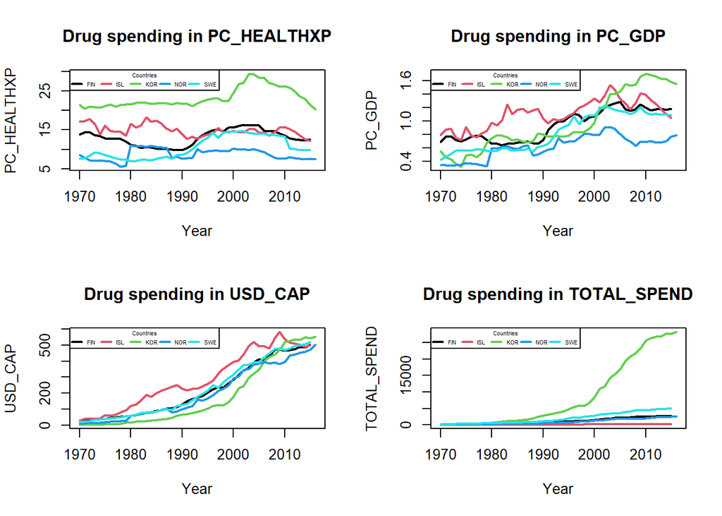

```r
par(mfrow = c(2, 2))
#create the  4 plot with one for :

for(i in metrics) {
  main_=paste( "Drug spending in",i)
  xlab_= "Year"
  ylab_=paste(i)
  xlim_=range(Drugstop13$TIME)
  ylim_=range(Drugstop13[,i])
  plot(0, 0, type = "n", xlim = xlim_, ylim = ylim_,    # 0,0,type="n" creates empty plot
       xlab = xlab_, ylab = ylab_, main = main_)


  locationlevels<-levels(as.factor(Drugstop13$LOCATION))       #or with the command  unique(Drugstop13$LOCATION)


  for (j in locationlevels) {
    Drugstop13_loclevels<-Drugstop13[Drugstop13$LOCATION== j ,]    # or with the command Subset data for the specific country #country_data <- subset(Drugstop13, LOCATION == country)

    lines( Drugstop13_loclevels$TIME, Drugstop13_loclevels[, i], type = "l",  lty =1 ,pch = -1,lwd=2,
           col = (1:length(locationlevels))[match(j,locationlevels )])

#explanation of match function , if I didn't put [match(j,locationlevels )] it wouldn't match a color to but the points on the lines would alternate colors, the same on each line,
#it determines which unique country corresponds to the current iteration of the loop.


  }

  legend("topleft", legend =locationlevels,cex = 0.4,horiz = TRUE,lwd=2,
         col = 1:length(locationlevels),lty=1,pch = -1, title = "Countries")

}
```

### 5)Your client is a multinational pharmaceutical company. They are interested in theprobability that Greece (GRC) will increase its drug expenditure in at least 4 of the 5 following consecutive years, in order to assess the investing opportunities. Assume that we are atthe year following the last record for Greece. Estimate the probability of drug expenditure increase in any given year by the number of years where the expenditure was higher than the year before (note: this is not an appropriate way of estimating this probability, only use it for this assignment!). Create a list with the following elements, named accordingly: $Data: The data for Greece. $Years: The range (in years) of available data points for Greece, a vector with two elements,the minimum and maximum years.$DataPoints: The number of available data points for Greece.$YearlyProbs: The yearly probabilities of increase in expenditure, in all the four metrics available, thus a vector with 4 elements and names according to the metric.$FiveYearsProbs: The requested probabilities for all metrics, thus a vector with 4 elements and names according to the metric.Hint: functions diff() and dbinom().

```r
head(Drugs)
```

```
##   LOCATION TIME PC_HEALTHXP PC_GDP USD_CAP TOTAL_SPEND
## 1      AUS 1971      15.992  0.727  35.720      462.11
## 2      AUS 1972      15.091  0.686  36.056      475.11
## 3      AUS 1973      15.117  0.681  39.871      533.47
## 4      AUS 1974      14.771  0.755  47.559      652.65
## 5      AUS 1975      11.849  0.682  47.561      660.76
## 6      AUS 1976      10.920  0.630  46.908      658.26
```

```r
Data<-Drugs[LOCATION=="GRC",]  #Data: The data for Greece.   # or with the command-->  Data <- subset(Drugs, LOCATION == "GRC")
head(Data)                     #ok.
```

```
##     LOCATION TIME PC_HEALTHXP PC_GDP USD_CAP TOTAL_SPEND
## 340      GRC 1988      15.393  0.844 101.924     1023.01
## 341      GRC 1989      14.147  0.851 110.191     1111.77
## 342      GRC 1990      14.942  0.907 120.531     1229.03
## 343      GRC 1991      17.082  1.012 141.532     1460.60
## 344      GRC 1992      17.802  1.154 164.945     1715.27
## 345      GRC 1993      17.283  1.257 179.964     1882.50
```

```r
Years<-range(Data$TIME)   #Years: The range (in years) of available data points for Greece, a vector with two elements, the minimum and maximum years.
Years                     #ok.
```

```
## [1] 1988 2015
```

```r
DataPoints<-length(Data$TIME)  #DataPoints: The number of available data points for Greece. # or with the command nrow(Data)
DataPoints
```

```
## [1] 27
```

```r
#______________________________________
#Estimate the probability of drug expenditure increase in any given year by the number of years where the expenditure was higher than the year before
# first I will define a numeric vector that is essentially empty, so that I can fill it with the annual probabilities of increase in
#expenditure, in all the four metrics available
YearlyProbs<-c(0,0,0,0)                            #or with the command YearlyProbs <- numeric(4)
#επίσης θα πάρω το διάνυσμα με τα 4 metrics
metrics <- colnames(Data)
metrics<-metrics[c(-1,-2)]                          #remove the  LOCATION and TIME
metrics
```

```
## [1] "PC_HEALTHXP" "PC_GDP"      "USD_CAP"     "TOTAL_SPEND"
```

```r
table(Data$TIME)  # ΆΡΑ ΈΣΤΩ ΟΤΙ ΕΙΜΑΣΤΕ ΣΤΟ 2016
```

```
##
## 1988 1989 1990 1991 1992 1993 1994 1995 1996 1997 1998 1999 2000 2001 2002 2003
##    1    1    1    1    1    1    1    1    1    1    1    1    1    1    1    1
## 2004 2005 2006 2007 2009 2010 2011 2012 2013 2014 2015
##    1    1    1    1    1    1    1    1    1    1    1
```

#THE LOGIC: #I will create a loop where for each element of the metrics vector (in each iteration of the loop), #it will go and calculate for me if each year has a lower or higher expenditure than the next year (diff), #(the length of each vector resulting from diff will be 1 element smaller than length(metrics), ok, obviously) #after I’ll filter how many differences are positive>0, so how many years we had an increase, and sum this boolean vector # to give me the count (“length”) of how many increments we have #whenever I can calculate “increase probability” = number of successes (increase) / total number of differences (success or failure)

```r
for (i in 1:length(metrics)) {
  diafores_dapanwn <- diff(Data[, metrics[i]])        # diff() calculates in a vector the difference that each value has from its next value, essentially as a vector inside diff() I will put each metric column
  length_increase_years<- sum(diafores_dapanwn > 0)   # diafores_dapanwn is a boolean vector where it has TRUE, where diafores_dapanwn had positive values, i.e. increase , the sum of the elements of this vector (TRUE=1 , FALSE=0), gives me how many years we had an increase

  yearly_prob_per_metric <- length_increase_years /length(diafores_dapanwn)

  YearlyProbs[i] <- yearly_prob_per_metric                      # put it inside the vector
  names(YearlyProbs[i])<-metrics[i]
  }



names(YearlyProbs)<-c("PC_HEALTHXP", "PC_GDP","USD_CAP","TOTAL_SPEND")
YearlyProbs #ok
```

```
## PC_HEALTHXP      PC_GDP     USD_CAP TOTAL_SPEND
##   0.5769231   0.7692308   0.7692308   0.7692308
```

probability that Greece (GRC) will increase its drug expenditure in at least 4 of the 5 following consecutive years

the LOGIC: create an empty vector to put the probabilities for each metric that I will create from the magnifying glass in there I will make a loop where for each metric it will go and calculate the probability density function of the binomial distribution

we chose this particular distribution to model this experiment as we search for the probability of “expenditure increases” in AT LEAST 4 out of 5 years. P(4<=X<=5)= P(X=4)+P(x=5) This relation holds only when the x values are independent and distinct, and so we use the rule of probability of association to calculate the overall percentage probability. Well, every year an “experiment” is carried out.

Specifically : The binomial distribution models: let x be the number of successes (for us here success=“increase in spending”) in 1 sequence of n (independent) Bernoulli tests (here we have 5 tests (5 years)) with fixed probability of success p (in our case here “probability of increase” YearlyProbs for each metric) and failure q=1-p in all tests. (if ν=1 we have bernoulli)

dbinom(x, size, prob, log = FALSE) #dbinom gives the density x: vector of quantiles. size: number of trials (zero or more). prob: probability of success on each trial. dbinom(4:5, 5, YearlyProbs[i]) # Compute P(4<=X<=5)= P(X=4)+P(x=5) for X Binomial(4, YearlyProbs[i] ) sum(dbinom(46:54, 100, 0.5))

```r
# Use dbinom to estimate the probability of at least 4 increases in 5 years
FiveYearsProbs<-c(0,0,0,0)
for (i in 1:length(metrics)) {
  FiveYearsProbs_per_metric <- sum(dbinom(4:5, 5, YearlyProbs[i])) # Compute P(4<=X<=5)= P(X=4)+P(x=5) for each metric
  FiveYearsProbs[i] <- FiveYearsProbs_per_metric                   #put it inside the FiveYearsProbs
}

names(FiveYearsProbs)<-c("PC_HEALTHXP", "PC_GDP","USD_CAP","TOTAL_SPEND")
FiveYearsProbs
```

```
## PC_HEALTHXP      PC_GDP     USD_CAP TOTAL_SPEND
##   0.2982609   0.6733227   0.6733227   0.6733227
```

```r
#___________Create a list with the following elements, named accordingly___________
erwtima5 <- list(
  Data = Data,
  Years = Years,
  DataPoints = DataPoints,
  YearlyProbs = YearlyProbs,
  FiveYearsProbs = FiveYearsProbs
)

# Print the list
print(erwtima5)
```

```
## $Data
##     LOCATION TIME PC_HEALTHXP PC_GDP USD_CAP TOTAL_SPEND
## 340      GRC 1988      15.393  0.844 101.924     1023.01
## 341      GRC 1989      14.147  0.851 110.191     1111.77
## 342      GRC 1990      14.942  0.907 120.531     1229.03
## 343      GRC 1991      17.082  1.012 141.532     1460.60
## 344      GRC 1992      17.802  1.154 164.945     1715.27
## 345      GRC 1993      17.283  1.257 179.964     1882.50
## 346      GRC 1994      16.730  1.335 198.096     2082.57
## 347      GRC 1995      16.305  1.300 200.210     2114.65
## 348      GRC 1996      16.693  1.315 212.121     2250.35
## 349      GRC 1997      16.871  1.298 222.511     2372.25
## 350      GRC 1998      14.475  1.097 197.608     2118.46
## 351      GRC 1999      15.079  1.171 216.130     2325.93
## 352      GRC 2000      19.871  1.439 280.723     3033.44
## 353      GRC 2001      19.075  1.524 320.158     3477.60
## 354      GRC 2002      19.949  1.643 371.489     4049.98
## 355      GRC 2003      21.388  1.753 418.525     4573.67
## 356      GRC 2004      23.038  1.827 465.174     5096.05
## 357      GRC 2005      22.338  2.010 514.010     5647.59
## 358      GRC 2006      23.613  2.117 604.089     6657.28
## 359      GRC 2007      25.798  2.337 684.401     7561.59
## 360      GRC 2009      27.171  2.573 782.011     8685.81
## 361      GRC 2010      28.633  2.737 771.997     8585.64
## 362      GRC 2011      30.742  2.797 731.159     8119.45
## 363      GRC 2012      29.055  2.550 644.747     7121.24
## 364      GRC 2013      27.742  2.312 603.509     6617.60
## 365      GRC 2014      26.701  2.120 560.435     6104.49
## 366      GRC 2015      25.878  2.170 571.913     6188.60
##
## $Years
## [1] 1988 2015
##
## $DataPoints
## [1] 27
##
## $YearlyProbs
## PC_HEALTHXP      PC_GDP     USD_CAP TOTAL_SPEND
##   0.5769231   0.7692308   0.7692308   0.7692308
##
## $FiveYearsProbs
## PC_HEALTHXP      PC_GDP     USD_CAP TOTAL_SPEND
##   0.2982609   0.6733227   0.6733227   0.6733227
```

### 6) Your client asks for a function that can calculate the above probabilities for a variable amount of years and for any country desired. Create a function that takes as arguments (and default values): COUNTRY=NULL: The country code of the variable called LOCATION. METRIC=PC HEALTHXP: The metric in which the required probability needs to be reported. Possible values should be “PC HEALTHXP” (% of health spending), “PC GDP” (% of GDP), “USD CAP” (absolute expenditure per capita), and “TOTAL SPEND” (total absolute spending). nofY=5: The number of following consecutive years that the probability needs to be estimated. Every time the probability estimated should be of the form “The probability of increasing drug expenditure in at least nofY-1 out of the following nofY years”.The outcome of the function should be a sentence of the form: “Based on (X) datapoints from years (minYear) to (maxYear), the probability that (countrycode) will increase its drug expenditure, in terms of (metric chosen), in at least (nofY-1) years in the period (maxYear+1) to (maxYear+1+nofY) is (estimated probability)”.If the number of available datapoints for the calculation of the yearly increase probability is less than 10 (thus, less than 11 years of data), the function should return: “Unable to calculate probability (n<10)”, without any other output. Hint: function paste(). (2.5 points)

```r
myfunc<-function(COUNTRY = NULL, METRIC = "PC_HEALTHXP", nofY = 5) {

  if(is.null(COUNTRY)){
   return("Unable to calculate probability ,give me a country")
  }
  metrics <- colnames(Data)
  metrics<-metrics[c(-1,-2)]

  #METRIC %in% valid_metrics checks if the value of the METRIC argument is one of the  metrics names.
  #It returns TRUE if METRIC is valid, and FALSE if it's not.
   if (!(METRIC %in% metrics )) {
    return("the dedault mteric that this function use is the PC_HEALTHXP ")
   }


  Data<-Drugs[LOCATION==COUNTRY,]  #Data: The data for THE COUNTRY THAT WE WANT
  DataPoints<-length(Data$TIME)
  Years <- range(Data$TIME)
  if (DataPoints < 10) {
    return("Unable to calculate probability (n<10)")
  }

 #we have the logic of the probs from the previous question :

    diafores_dapanwn <- diff(Data[, METRIC])
    length_increase_years<- sum(diafores_dapanwn > 0)
    YearlyProbs <- length_increase_years /length(diafores_dapanwn)


  FiveYearsProbs <- sum(dbinom((nofY - 1):nofY, nofY, YearlyProbs))

  erwt6 <- paste(
    "Based on", DataPoints, "datapoints from years", Years[1], "to", Years[2],
    "the probability that", COUNTRY, "will increase its drug expenditure,",
    "in terms of", METRIC, "in at least", nofY - 1,
    "years in the period", Years[2] + 1, "to", Years[2] + nofY,
    "is", FiveYearsProbs
  )

  return(erwt6)

}


# e.g.
grc_result <- myfunc(COUNTRY = "GRC", METRIC = "PC_HEALTHXP", nofY = 5)
print(grc_result) # ok , the result it's the same with the question 5
```

```
## [1] "Based on 27 datapoints from years 1988 to 2015 the probability that GRC will increase its drug expenditure, in terms of PC_HEALTHXP in at least 4 years in the period 2016 to 2020 is 0.298260908500834"
```